# R Notebook

> Sede San Carlos  
> Matematica para Ciencia de los Datos  
> Proyecto II  
> Autor: Andres Gonzalez  
> 2019

### I Parte

**1.** Se le pidió a un grupo de 100 clientes que compraron el mismo producto o productos similares en la tienda de AMAZON, que evaluaran el servicio recibido desde diferentes aspectos. El archivo EjemploAlgoritmosRecomendacion.csv muestra los promedios de la evaluación dada por los clientes en relación a las variables que se pueden apreciar en el encabezado de la tabla. Para este dataset, realice lo siguiente:

**a)** Cargue el dataset EjemploAlgoritmosRecomendacion.csv, verifique que la lectura de los datos es correcta.

```r
algoritmos <- read.csv("datos/EjemploAlgoritmosRecomendacion.csv", sep = ";", dec = ",", header = T,row.names = 1)
head(algoritmos)
```

|  | Velocidad.Entrega | Precio | Durabilidad | Imagen.Producto | Valor.Educativo | Servicio.Retorno | Tamano.Paquete | Calidad.Producto | Numero.Estrellas |
| --- | --- | --- | --- | --- | --- | --- | --- | --- | --- |
| Adam | 2.05 | 0.30 | 3.45 | 2.35 | 2.4 | 2.3 | 2.60 | 2.10 | 1.7 |
| Anna | 0.90 | 1.50 | 3.15 | 3.30 | 2.5 | 4.0 | 4.20 | 2.15 | 2.8 |
| Bernard | 1.70 | 2.60 | 2.85 | 3.00 | 4.3 | 2.7 | 4.10 | 2.60 | 3.3 |
| Edward | 1.35 | 0.50 | 3.55 | 2.95 | 1.8 | 2.3 | 3.90 | 1.95 | 1.7 |
| Emilia | 3.00 | 0.45 | 4.80 | 3.90 | 3.4 | 4.6 | 2.25 | 3.40 | 4.3 |
| Fabian | 0.95 | 1.65 | 3.95 | 2.40 | 2.6 | 1.9 | 4.85 | 2.20 | 3.0 |

**b)** A manera de diagnóstico, haga una inspección de los datos presentes en el dataset y describa las variables presentes, tipos de variables, si hay datos nulos.

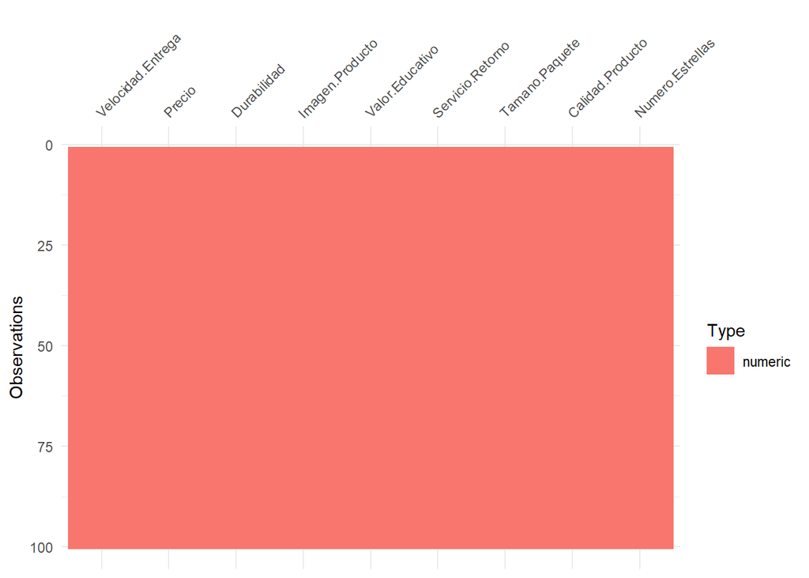

```r
vis_dat(algoritmos)
```

**c)** Determine si existen correlaciones importantes entre las variables del dataset, utilizando alguno de los gráficos o la matriz de correlaciones vistos en clases (si desea, puede usar otra herramienta de su preferencia). Recordemos que para aplicar un ACP, es importante que existan correlaciones entre las variables.

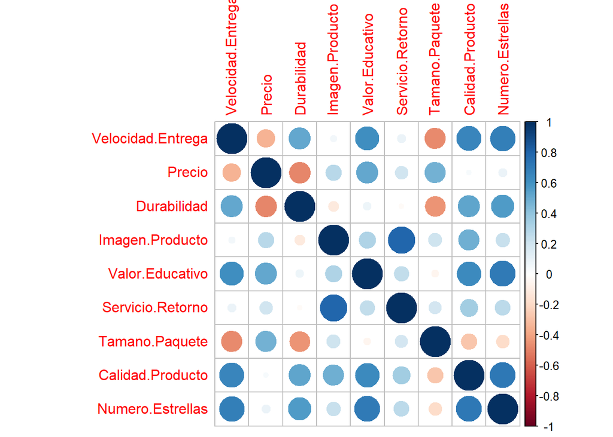

```r
correlaciones <- round(cor(algoritmos), 2)
corrplot::corrplot(correlaciones)
```

**d)** Realice un ACP usando el paquete FactoMiner, creando el plano principal y el círculo de correlaciones. Superponga ambos gráficos e identifique la cantidad de clústeres que considere apropiado. Haga un análisis descriptivo de cada clúster, indique si hay variables correlacionadas y el tipo de correlación entre estas.

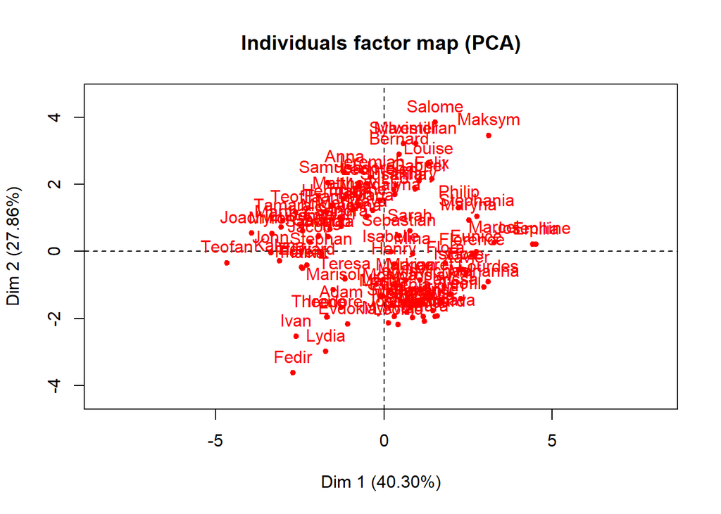

```r
pca_alg <- PCA(algoritmos, scale.unit=TRUE, ncp=5, graph = FALSE)
plot(pca_alg, axes=c(1, 2), choix="ind", col.ind="red",new.plot=TRUE)
```

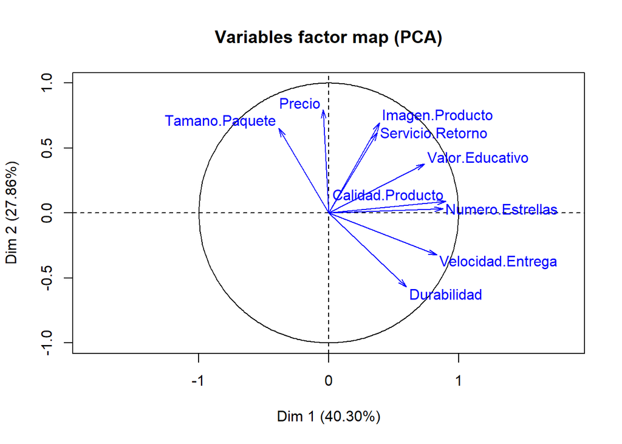

```r
plot(pca_alg, axes=c(1, 2), choix="var", col.var="blue",new.plot=TRUE)
```